# TMA4300 Comouter Intensive Statistical Methods

Exercise 1

Maja B. Mathiassen & Elsie B. Tandberg

# 1 Problem A

## 1.1 1

We will write a function that generates n samples from an exponential distribution with rate parameter $\lambda$.

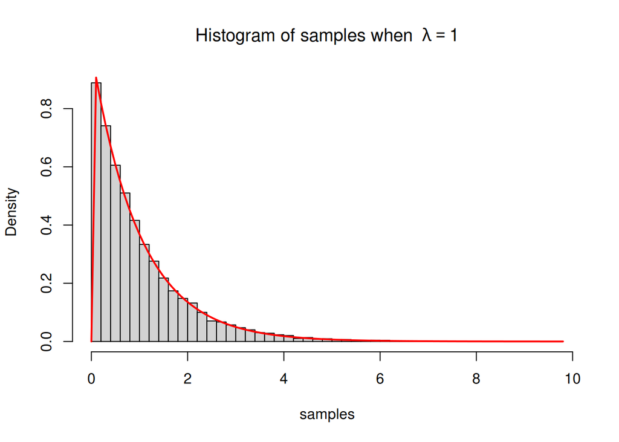

Figure 1.1: Comparing theoretical curve (red) to a histogram of our generated samples.

```r
#Function that generates n samples from the exponential distribution
exponential <- function(lambda, n) {
  #Sampling from the uniform distribution U[0,1]
  u = runif(n)
  #Converting to log scale for more efficient calculation
  x = -1/lambda * log(u)
  return(x)
}

#Testing the function for the exponential distribution
test_exponential = function(lambda, n) {
  samples = exponential(lambda, n) # sample from an exponential distribution
  hist(samples, breaks = 50, freq = FALSE, main = bquote("Histogram of samples when "~lambda == .(lambda)))
  curve(dexp(x, lambda), col = "red", lwd = 2, add=TRUE)
  return(samples)
}

lambda=1
s = test_exponential(lambda, 10000)
```

Figure (1.1) shows a histogram of our samples. The red line corresponds to the pdf of an exponential distribution, and overlaps with the histogram in a way that suggests our samples could be exponentially distributed as well. In addition we know the mean and variance of the exponential distribution. When $X\sim\text{Exp}(\lambda)$, and $\lambda=$ 1, then $E[X]=1/\lambda=$ 1 and $Var[X]=1/\lambda^2=$ 1. Our samples have mean 1.0061612 and variance 1.0056114, which is fairly close to the theoretical values.

## 1.2 2(a)

Given the probability density function g(x),
$$g(x)= \begin{cases}
cx^{\alpha-1} & 0< x< 1 \\
ce^{-x} & 1\leq x \\
0 & \text{otherwise }
\end{cases}$$

The cumulative distribution function, G(x), is found by integration
$$\begin{aligned}
G(x)&=\begin{cases}
\int_0^x cx^{\alpha-1}dx &0<x<1\\
\int_0^1 cx^{\alpha-1}dx+\int_1^xce^{-x}dx &1\le x\\
0 & \text{otherwise}\\
\end{cases}\\
&=\begin{cases}
\frac{1}{\alpha}cx^{\alpha} & 0<x<1\\
1-ce^{-x} & 1\le x\\
0 &\text{otherwise}
\end{cases}
\end{aligned}$$
The inverse cumulative distribution function is found by solving G(x) for x.
$$\begin{aligned}
G(x)&=\frac{1}{\alpha}cx^{\alpha}=u, \text{ for }x \in (0,1)\\
x&=(\frac{\alpha u}{c})^{\frac{1}{\alpha}}.
\end{aligned}$$
$$\begin{aligned}
G(x)&=1-ce^{-x}=u, \text{ for }1\le x\\
x&=\text{ln}(c)-\text{ln}(1-u).
\end{aligned}$$
## 2(b) Next we write a function that generates samples from $g$. We have found the normalizing constant $c=\frac{1}{1/\alpha + e^{-1}}$.

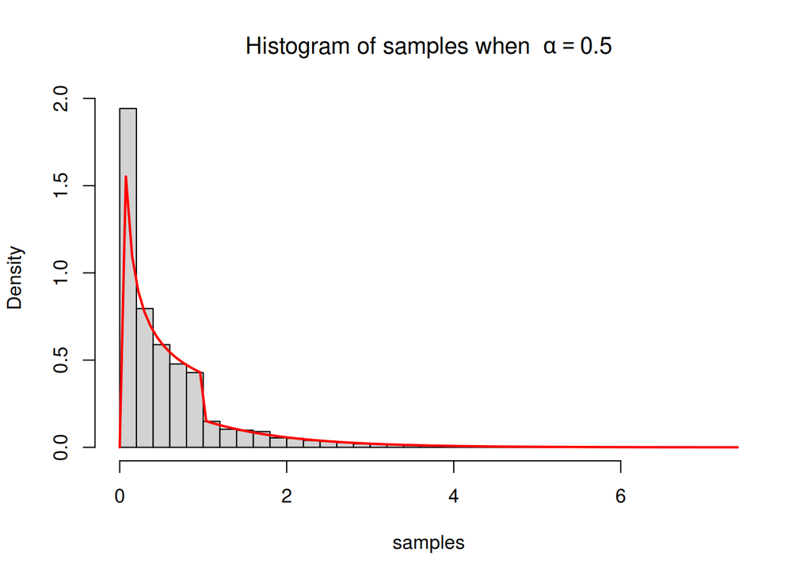

Figure 1.2: Plot of teoretical sample from g in red line, and histogram of our samples generated from g.

```r
#Function that samples from g(x)
sampleA2 = function(alpha, n) {
  #Defining the normalizing constant
  c = 1 / (1/alpha + exp(-1))
  G = 1 - c*exp(-1) # G(1)
  u = runif(n)
  #x is a sample from g(x)
  x = ifelse(u<G, (alpha/c * u)^(1/alpha), log(c) - log(1-u))
  return (x)
}

#Function that generates theoretical values directly from g used to test our sample.
g_A2 = function(alpha, x) {
  c = 1 / (1/alpha + exp(-1))
  g = ifelse(0<x & x<1, c*x^(alpha-1), ifelse(x>=1, c*exp(-x), 0))
  return (g)
}

#Testing our sample from g by plotting a histogram of our sample and a theoretical curve
test_A2 = function(alpha, n) {
  #Sampling from g
  samples = sampleA2(alpha, n)
  hist(samples, breaks = 50, freq = FALSE, main = bquote("Histogram of samples when "~alpha == .(alpha)))
  #Adding curve with true values from g
  curve(g_A2(alpha, x), col = "red", lwd = 2, add=TRUE)
}

alpha = 0.5
test_A2(alpha, 10000)
```

The red line is the function $g(x)$, which we wish to sample from. The histogram shows our samples, and corresponds well with the red line.

## 1.3 3(a)

The normalizing constant $c$ will make the value of the integral of $f(x)$ equal to 1.
$$\begin{aligned}
\int_{-\infty}^{\infty}f(x)&=\int_{-\infty}^{\infty}\frac{ce^{\alpha x}}{(1+e^{\alpha x})^2}dx && \text{Substitute } u=e^{\alpha x}+1\\
&=\frac{c}{\alpha}\int_{-\infty}^{\infty}\frac{1}{u^2}du\\
&=\frac{c}{\alpha}\bigg[-\frac{1}{e^{\alpha x}+1}\bigg]_{-\infty}^{\infty}\\
&=\frac{c}{\alpha}
\end{aligned}$$
In order for this integral to be one we have to have $c=\alpha$.

## 1.4 3(b)

Finding the cumulative distribution function, $F(x)$, of the pdf $f(x)$, by integrating $f(x)$ up to $x$.The calculations are similar to the previous one.
$$\begin{aligned}
F(x)=\int_{-\infty}^{x}f(x)&=\int_{-\infty}^{x}\frac{\alpha e^{\alpha x}}{(1+e^{\alpha x})^2}dx\\
&=\frac{\alpha}{\alpha}\bigg[-\frac{1}{e^{\alpha x}+1}\bigg]_{-\infty}^{x}\\
&=\frac{e^{\alpha x}}{e^{\alpha x}+1}
\end{aligned}$$
The inverse function of $F$ is found by solving the equation for $x$.

$$\begin{aligned}
u&=\frac{e^{\alpha x}}{e^{\alpha x}+1}\\
e^{\alpha x }&=\frac{u}{u-1}&\\
x&=\frac{log(\frac{-u}{u-1})}{\alpha}.
\end{aligned}$$
## 3(c)

We will write a function that generates samples from $f$, using the inverse found above.

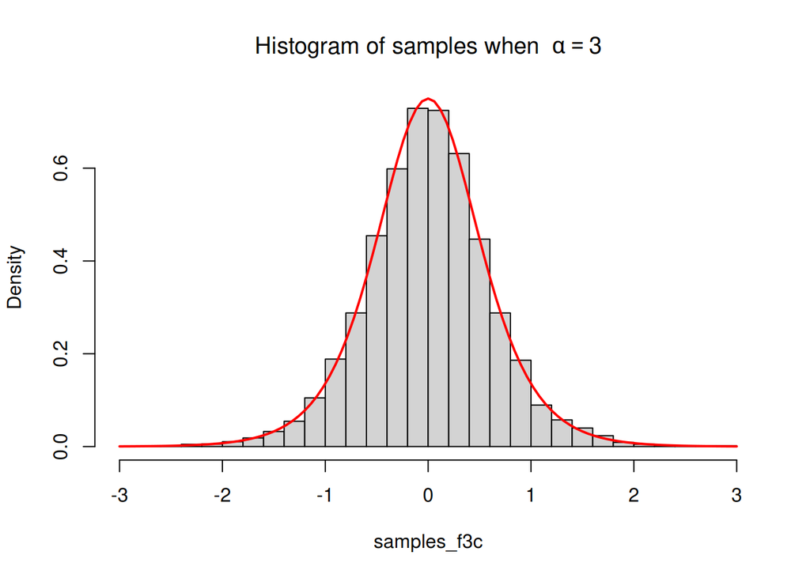

Figure 1.3: Plot of teoretical sample from f in red line, and histogram of our samples generated grom f.

```r
#Writing a function that generates n samples from f.
f3c <- function(alpha, n){
    u<-runif(n)
    x <- log(-u/(u-1))/alpha
    return(x)
}

#function that generates values directly from f(x), used to compare.
curve_f3c <-function(alpha,x){
  return((alpha*exp(alpha*x))/(1+exp(alpha*x))^2)
}

test_f3c <-function(alpha,n){
  samples_f3c <- f3c(alpha,n)
  hist(samples_f3c, breaks = 30, freq = FALSE, main = bquote("Histogram of samples when "~alpha == .(alpha)))
  #Adding curve with true values from g
  curve(curve_f3c(alpha, x), col = "red", lwd = 2, add=TRUE)
}

test_f3c(3,10000)
```

The histogram of our computed samples from $f$ match the theoretical curve. This means that our function is working properly.

## 1.5 4

We will write a function that generates a vector of $n$ independent samples from the standard normal distribution using the Box-Muller algorithm.

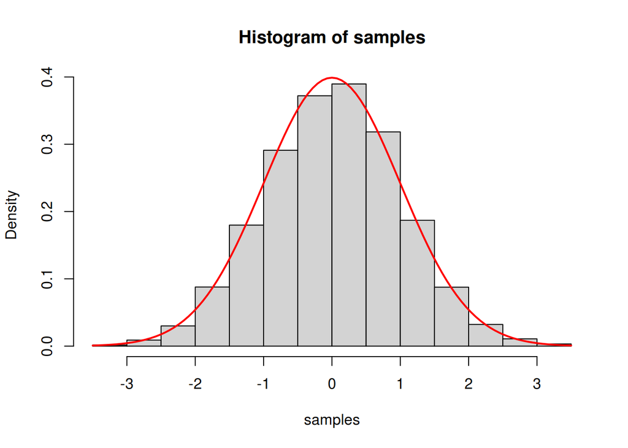

Figure 1.4: Plot of histogram of our samples from the standard normal distribution and a theoretical curve from the same distribution.

```r
#Function that uses Box-Muller algorithm to generate a vector of n independent samples from the
#standard normal distribution.
box_muller = function(n) {
  # Assume n is an even number
  m = n/2

  x1 = runif(m) * 2*pi
  x2 = exponential(0.5, m)

  y1 = sqrt(x2) * cos(x1)
  y2 = sqrt(x2) * sin(x1)

  y = c(y1, y2)
  return(y)
}


#Function that tests our implementation
test_box_muller = function(n) {
  samples = box_muller(n) # sample from N(0,1)
  hist(samples, freq = FALSE)
  curve(dnorm(x, mean=0, sd=1), col = "red", lwd = 2, add=TRUE)
  return(samples)
}

s = test_box_muller(10000)
```

The above histogram shows the samples generated from the Box-Muller algorithm. Most of the samples lie close to 0, and the histogram is fairly symmetric, which is the case for a $N(0,1)$ distribution. The red line which represents the actual $N(0,1)$ distribution follows the histogram very well. Additionally, we know the distribution have mean 0 and variance 1. Our samples have mean 0.0231079 and the variance is 0.9882939, which are close to the theoretical values.

## 1.6 5

We can use the Box Muller algorithm in order to simulate from a $N_d(\vec\mu, \Sigma)$ distribution. If $X\sim N_d(0,1)$, then $Y=\vec\mu+AX$ is from $N_d(\mu,AA^T)$. If $A$ is the Cholesky decomposition of $\Sigma$, then $AA^T=\Sigma$.

```r
multivariate = function(mu, sigma, d, n) {
  A = chol(sigma) # A is a Cholesky decomposition of sigma
  X = matrix(0, nrow=d, ncol=n)
  for (i in 1:n) {
    X[,i] = box_muller(d) # uses box muller to find a vector of d values from N(0,1)
  }
  Y = t(mu + t(A) %*% X)
  return (Y)
}

d = 2
mu = c(1,2)
sigma = cbind( c(2, 1), c(1, 3))
sim = multivariate(mu, sigma, 2, 100000)
```

In order to test our implementation we look at
$$\begin{aligned}
\vec\mu = \begin{pmatrix}
1 \\
2
\end{pmatrix} \quad
\Sigma = \begin{pmatrix}
2 & 1 \\
1 & 3
\end{pmatrix}
\end{aligned}$$
If $X\sim N_d(\vec\mu, \Sigma)$, then $E[X]=\vec\mu$ and $Var[X]=\Sigma$. Our simulated data have mean 0.9944405, 1.9937265 and variance

```r
var(sim)
```

```
##           [,1]      [,2]
## [1,] 1.9927795 0.9966877
## [2,] 0.9966877 2.9892283
```

This is close to the theoretical values so we make the conclusion that our algorithm is correct.

# 2 Problem B

## 2.1 1(a)

Here, we look at the gamma distribution with $\alpha\in(0,1)$ and $\beta=0$, which had pdf
$$f(x)= \begin{cases}
\frac{1}{\Gamma(\alpha)}x^{\alpha-1}e^{-x} & 0< x\\
0 & \text{otherwise. }
\end{cases}$$

Finding an expression for the acceptance probability, $\tau$.
$$\begin{aligned}
\frac{f(x)}{g(x)}&\le d
\le \begin{cases}
\frac{1}{c\Gamma(\alpha)}e^{-x} & 0< x< 1 \\
\frac{1}{c\Gamma(\alpha)}x^{\alpha -1} & 1\leq x \\
0 & \text{otherwise. }
\end{cases}\\ \\
\end{aligned}$$
Considering the limits on $x$, we obtain the following inequalities

$$\begin{aligned}
\frac{1}{c\Gamma(\alpha)}e^{-x}\le \frac{1}{c\Gamma(\alpha)}=d && \frac{1}{c\Gamma(\alpha)}x^{\alpha -1}\le\frac{1}{c\Gamma(\alpha)}=d.
\end{aligned}$$
The acceptance probability is given by
$$\begin{aligned}
\tau&=\begin{cases}
\frac{1}{d}\frac{1}{c\Gamma(\alpha)}e^{-x}\\
\frac{1}{d}\frac{1}{c\Gamma(\alpha)}x^{\alpha -1}\\
0
\end{cases}\\
&=\begin{cases}
e^{-x}\\
x^{\alpha -1}\\
0
\end{cases}
\end{aligned}$$
## 1(b)

We can simulate from the gamma distribution using rejection sampling.

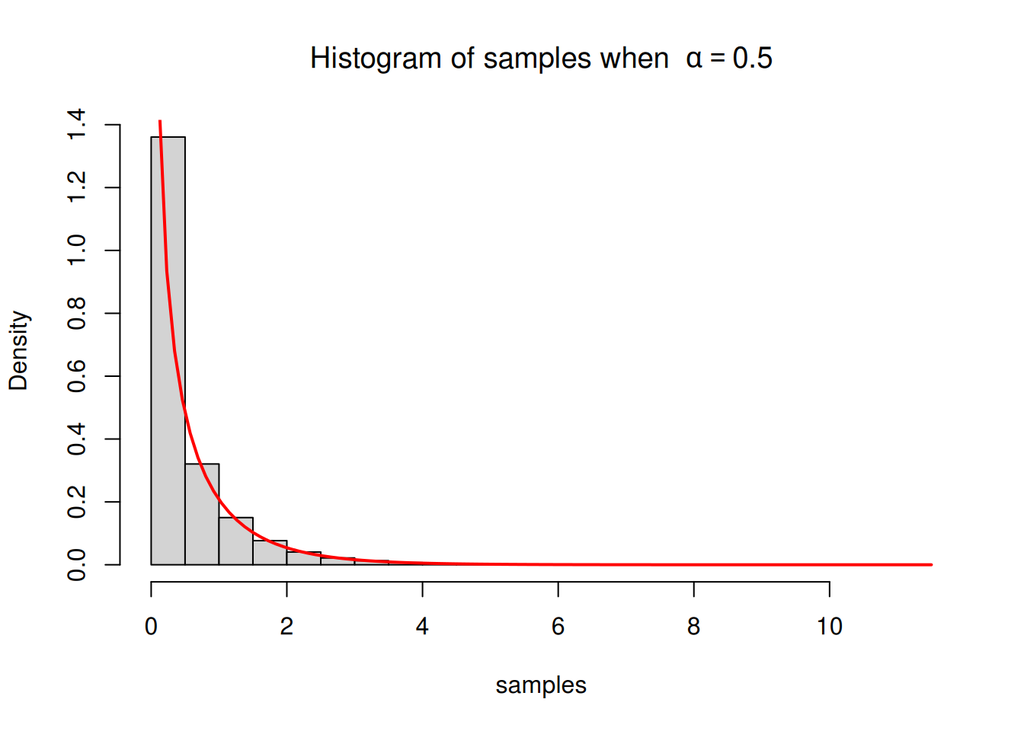

Figure 2.1: Histogram of our sample from the gamma distribution, and a red curve showing the theoretical distribution.

```r
#Function that samples from the gamma distribution
sampleB1 = function(alpha) {
  accept = 0
  while (accept == 0) {
    # generate x from g(x)
    x = sampleA2(alpha, 1)

    # generate u from U[0,1]
    u = runif(1)

    # find acceptance prob a
    a = ifelse(x<1, exp(-x), x^(alpha-1))

    # if u<=a, accept
    if (u<=a) {
      accept = 1
    }
  }
  return (x)
}

#Function that finds n samples of the gamma distribution
gammaB1 = function(alpha, n) {
  X = 1:n

  for (i in 1:n) {
    X[i] = sampleB1(alpha)
  }

  return (X)
}

#Function that tests the implementation
testB1 = function(alpha, n) {
  # Know that if X~Gamma(alpha, 1), then E[X] = alpha and Var[X] = alpha
  samples = gammaB1(alpha, n)
  hist(samples, breaks = 40, freq = FALSE, main = bquote("Histogram of samples when "~alpha == .(alpha)))
  curve(dgamma(x, alpha, 1), col = "red", lwd = 2, add=TRUE)
  return(samples)
}

alpha = 0.5
s = testB1(alpha, 100000)
```

If $X\sim\text{Gamma}(\alpha, \beta)$ then $E[X] = \alpha/\beta$ and $Var[E]=\alpha/\beta^2$. Here $\alpha =$ 0.5 and $\beta=1$, which means that $E[X]=Var[X]=$ 0.5. Our samples have mean 0.5032734 and variance 0.5032643.

From the plot we see that our sample matches the theoretical distribution, so our function is correct.

## 2.2 2(a)

We will now use the ratio of uniforms method to simulate from the gamma distribution with parameters $\alpha>1$ and $\beta=1$. We have

$$C_f=\begin{cases}(x_1,x_2):0\le x_1\le \sqrt{f^*\bigg(\frac{x_2}{x_1}\bigg)}
\end{cases} \text{ where }
f^*(x)=\begin{cases}x^{\alpha-1}e^{-x},& 0<x\\
0, & \text{ otherwise}
\end{cases}$$
and
$$\begin{aligned}
a&=\sqrt{\sup_{0<x}f^*(x)}= \sqrt{\sup_{0<x}(x^{\alpha-1}e^{-x})} \\
b_+&=\sqrt{\sup_{0\le x}(x^2f^*(x))} =\sqrt{\sup_{0\le x}(x^2x^{\alpha-1}e^{-x})}\\
b_-&=\sqrt{\sup_{x<0}(x^2f^*(x))}=\sqrt{\sup_{x<0}(x^2\cdot0)} = 0.
\end{aligned}$$
The values of $a$, $b_+$ and $b_-$ are found by derivation of $f^*(x)$ and $x^2f^*(x)$, setting the equations equal to zero and solving for x.
$$\begin{aligned}
\frac{d}{dx}f^*(x)=0 && \frac{d}{dx}x^2f^*(x)=0\\
\frac{d}{dx}(x^{\alpha-1}e^{-x})=0 && \frac{d}{dx}(x^2x^{\alpha-1}e^{-x})=0 \\
x=\alpha-1 && x=\alpha+1\\
\end{aligned}$$
$$\begin{aligned}
a&=\sqrt{(\alpha-1)^{\alpha-1}e^{1-\alpha}}\\
b_+&=\sqrt{(\alpha+1)^{\alpha+1}e^{-1-\alpha}}\\
b_-& = 0
\end{aligned}$$
## 2(b)

To write a function that generates samples from $f$ we sample $x_1\sim U[0,a]$ and $x_2\sim U[0,b_+]$ and check if the samples are in $C_f$. Then the accepted samples will have the property that $\frac{x_2}{x_1}\sim Gamma(\alpha, 1)$. The algorithm will be implemented on log-scale to be able to handle large values for $\alpha$. To sample from $U[0,a]\times U[0,b_+]$, when we have $u\sim U[0,1]$ we have that

$$\begin{aligned}
x_1&=a+u_1\\
log(x_1)&= log(a)+log(u_1)\quad \text{on log scale.}\\
&=\frac{1}{2}((\alpha-1)log(\alpha-1)+(1-\alpha))+log(u_1)\\
x_2&=b_+ +u_2\\
log(x_2) &= log(b_+)+log(u_2)\quad \text{on log scale.}\\
&=\frac{1}{2}((\alpha+1)log(\alpha+1)-1-\alpha))+log(u_2)
\end{aligned}$$
The acceptance criteria is found by checking that $(x_1, x_2)\in C_f$. This is true when we have the inequality

$$\begin{aligned}
x_1&\le \sqrt{\frac{x_2^{\alpha-1}e^{-x_2}}{x_1^{\alpha-1}e^{-x_1}}}\\
2log(x_1)&\le(\alpha-1)(log(x_2)-log(x_1))-e^{log(x_2)-log(x_1)} \quad \text{on log scale.}
\end{aligned}$$

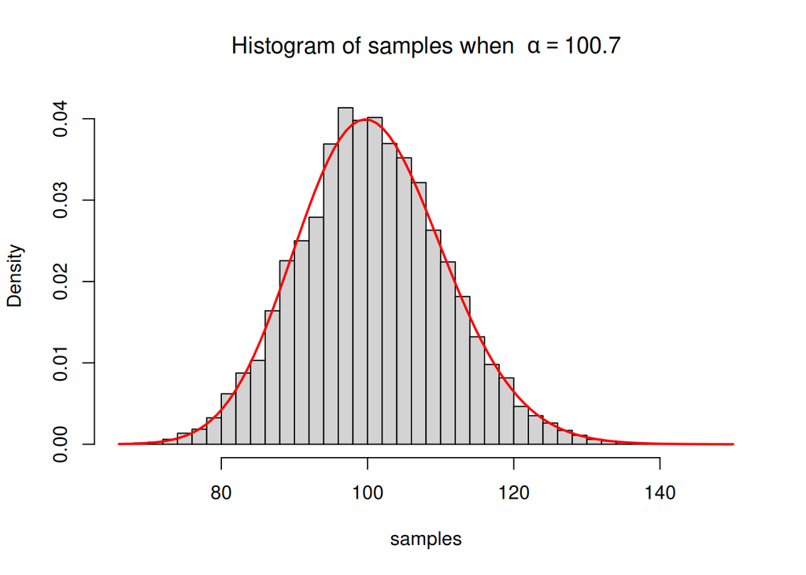

Figure 2.2: Plot from the gamma distribution for large value of alpha=100.7, with a histogram of our samples and a theoretical curve.

```r
#Function that samples from the gamma distribution
gammaB2 <- function(alpha, n){
  #Defining a and b+ on log scale
  loga <- 1/2*((alpha-1)*log(alpha-1)+(1-alpha))
  logb <- 1/2*((alpha+1)*log(alpha+1)-1-alpha)

  accept=c()#vector of accepted values
  tries=1
  count = 1
  while(length(accept)<n){
    #Converting to uniform distribution with correct limits
    logx1 <- loga + log(runif(1))
    logx2 <- logb + log(runif(1))
    #Proposal sample from the gamma distribution
    y<-exp(logx2-logx1)
    a <- (alpha-1)*(logx2-logx1)-exp(logx2-logx1)#acceptance criteria
    if(2*logx1<=a){
      accept[count]<-y
      count = count +1
    }
    tries=tries+1
  }
  return(cbind(accept,tries-1))
}

#Function that tests the implementation
testB2 = function(alpha, n) {
  samples = gammaB2(alpha, n)[,1]
  hist(samples, breaks = 40, freq = FALSE, main = bquote("Histogram of samples when "~alpha == .(alpha)))
  curve(dgamma(x, alpha, 1), col = "red", lwd = 2, add=TRUE)
  return(samples)
}

alpha = 100.7
s = testB2(alpha, 10000)
```

Here $\alpha =$ 100.7 and $\beta=1$, which means that $E[X]=Var[X]=$ 100.7. Our samples have mean 100.6687023 and variance 99.5130725.

```r
#Function for testing number of tries for each value of alpha
testf <- function(){
alphas = 2:2000
num_tries = data.frame(alphas,tries=0)
for(i in alphas){
  try = f(1000,alphas[i-1])[1,2]
  num_tries[i-1,2]<-try
}
return(num_tries)
}
#testing_large_alphas<- testf() HUSK Å FJERNE!!!
#plot(testing_large_alphas)
```

## 2.3 3

In order to sample from the gamma distribution when $\alpha>0$, we can use the previous implementations, as well as the fact that $Gamma(1,1)$ is equivalent with $Exp(1)$. Since we want to sample when $\beta>0$, not just when $\beta=1$, we use that if $X\sim Gamma(\alpha, 1)$, then $Y=X/\beta\sim Gamma(\alpha,\beta)$.

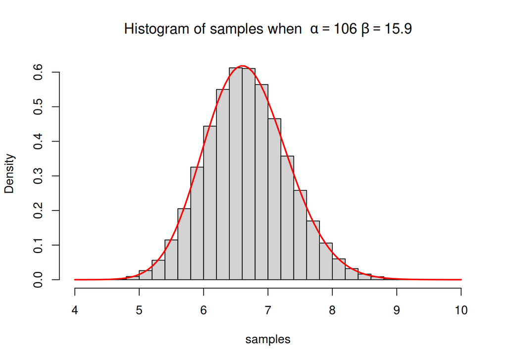

Figure 2.3: Histogram of samples from gamma(106,15.9), compared to theoretical curve.

```r
#Function that samples from the gamma distribution
gammaB3 = function(alph, bet, n) {
  if (alph<0) {
    X = gammaB1(alph, n) # sample from a Gamma(alpha, 1) distribution, 0<alpha<1
  }
  else if (alph == 1) {
    X = exponential(1, n) # Gamma(1,1) is equivalent with Exp(1)
  }
  else {
    X = gammaB2(alph, n)[,1] # sample from Gamma(alpha, 1), 1<=alpha
  }
  Y = X/bet # Y contains n samples from Gamma(alpha, beta), alpha>0, beta>0

  return(Y)
}

#Function that tests the implementation
testB3 = function(alp, bet, n) {
  # X ~ Gamma(a, b), E[X] = a/b, Var[X] = a/b^2
  samples = gammaB3(alp, bet, n)

  hist(samples, breaks = 40, freq = FALSE, main = bquote("Histogram of samples when "~alpha == .(alp) ~beta ==.(bet)))
  curve(dgamma(x, alp, bet), col = "red", lwd = 2, add=TRUE)
  return(samples)
}

a = 106
b = 15.9
s = testB3(a,b,100000)
```

Now $\alpha =$ 106 and $\beta=$ 15.9, which means that $E[X]=$ 6.6666667 and $Var[X]=$0.4192872. Our samples have mean 6.6714249 and variance 0.4166876.

Looking at the plot we see that the histogram of our realizations match with the theoretical values.

## 2.4 4(a)

$X\sim\text{Gamma}(\alpha,1)$ and $Y\sim\text{Gamma}(\beta,1)$. The joint distribution function is
$$\begin{aligned}
f_{X,Y}(x,y)=f_X(x)f_Y(y) = \frac{1}{\Gamma(\alpha)\Gamma(\beta)}x^{\alpha-1}y^{\beta-1}e^{-x-y}.
\end{aligned}$$
We define
$$\begin{aligned}
U=\frac{X}{X+Y}=g(X,Y), \quad V=X+Y=h(X,Y)
\end{aligned}$$
which means that $X=UV=g^{-1}(U,V)$ and $Y=V(1-U)=h^{-1}(U,V)$. Then
$$f_{U,V}(u,v)=f_X(g^{-1}(u,v))f_Y(h^{-1}(u,v))|J|$$
where $J$ is the Jacobian, and
$$\begin{aligned}
|J| = \begin{vmatrix}
\partial g^{-1}/\partial u & \partial g^{-1}/\partial v \\
\partial h^{-1}/\partial u & \partial h^{-1}/\partial v
\end{vmatrix} = \begin{vmatrix}
v & u \\
-v &(1-u)
\end{vmatrix} = v(1-u) + uv = v.
\end{aligned}$$
Then the joint distribution of $U$ and $V$ becomes
$$\begin{aligned}
f_{U,V}(u,v)&=\frac{1}{\Gamma(\alpha)}(uv)^{\alpha-1}e^{-uv}\frac{1}{\Gamma(\beta)}(v(1-u))^{\beta-1}e^{-v(1-u)}v \\
&= \frac{1}{\Gamma(\alpha)\Gamma(\beta)}u^{\alpha-1}(1-u)^{\beta-1}v^{\alpha+\beta-1}e^{-v}.
\end{aligned}$$
which mean that
$$\begin{aligned}
f_U(u)&=\int_0^\infty f_{U,V}(u,v)dv = \frac{1}{\Gamma(\alpha)\Gamma(\beta)}u^{\alpha-1}(1-u)^{\beta-1}\int_0^\infty v^{\alpha+\beta-1}e^{-v}dv \\
&= \frac{1}{\Gamma(\alpha)\Gamma(\beta)}u^{\alpha-1}(1-u)^{\beta-1} \Gamma(\alpha+\beta).
\end{aligned}$$
This means that $U\sim\text{Beta}(\alpha,\beta)$.

## 2.5 4(b)

Using the result above we can sample from the beta distribution.

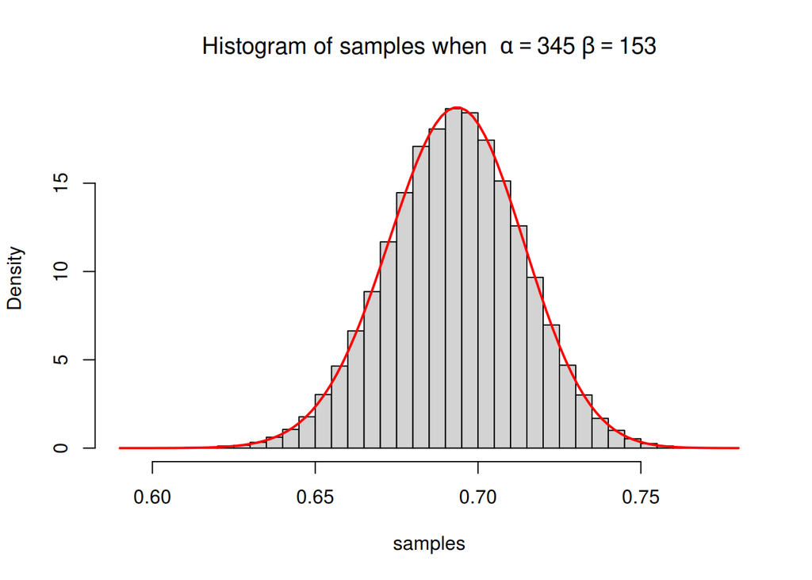

Figure 2.4: Plot from the beta distribution, with a histogram of our samples and a theoretical curve.

```r
#Function that samples from the beta distribution
betaB4 = function(alp, bet, n) {
  x = gammaB3(alp, 1, n)
  y = gammaB3(bet, 1, n)
  z = x / (x+y)

  return (z)
}

#Function that tests the implementation
testB4 = function(a, b, n) {
  # Note: X ~ Beta(a, b), then E[X] = a/(a+b), and Var[X] = ab/( (a+b)^2 (a+b+1) )
  samples = betaB4(a, b, n)

  hist(samples, breaks = 30, freq = FALSE, main = bquote("Histogram of samples when "~alpha == .(a) ~beta ==.(b)))
  curve(dbeta(x, a, b), col = "red", lwd = 2, add=TRUE)
  return(samples)
}

a = 345
b = 153
s=testB4(a, b, 100000)
```

When $X\sim\text{Beta}(\alpha,\beta)$, then $E[X]=\alpha/(\alpha+\beta)$ and $Var[X]=\alpha\beta/((\alpha+\beta)^2(\alpha+\beta+1))$.Here $\alpha =$ 345 and $\beta=$ 153, which means that $E[X]=$ 0.6927711 and $Var[X]=$4.265316810^{-4}. Our samples have mean 0.692696 and variance 4.290588810^{-4}.

The histogram of samples match the curve.

# 3 Problem C

## 3.1 C1)

We want $\theta=Prob(X>4)$, where $X~N(0,1)$

```r
#Indicator function required to count the number of samples above a limit
indicator_function<-function(x, limit){
  return(x>4)
}

monte_carlo<-function(n, limit){
  #Generate a vector of n independent samples from the standard normal distribution
  normal_samples <- box_muller(n)
  #Vector of length n with value true for samples above limit, and false otherwise
  samples_above <-indicator_function(normal_samples,limit)
  #Estimating theta by finding the mean
  theta_hat <- mean(samples_above)
  #Finding the sample variance
  theta_var <- var(samples_above)/(n-1)
  return(c(theta_hat,theta_var))
}


#Computing 95% confidence interval
confidence_interval<-function(theta_hat, theta_var){
  left<-theta_hat+qnorm(0.025)*sqrt(theta_var) #The left value of the interval
  right<-theta_hat+qnorm(0.975)*sqrt(theta_var) #The right value of the interval
  return(c(left,right))
}

#Testing the functions
test_mc<-monte_carlo(10^5,4)
conf_int <- confidence_interval(test_mc[1],test_mc[2])
conf_int
```

```
## [1] -3.947402e-06  6.394740e-05
```

The 95% confidence interval for $\theta$ based on these n samples is [-3.947402310^{-6}, 6.394740210^{-5}].

## 3.2 C2)

$$g(x)= \begin{cases}
cxe^{-0.5x^2} & 4< x \\
0 & \text{otherwise }
\end{cases}$$
The cumulative distribution function is given by
$$\begin{aligned}
G(x)&=\int_4^xcte^{-0.5t^2}dt\\
&=c (e^{-8}-e^{-0.x^2}) & \text{The normalizing constant, } &c=e^8 \text{, is found by setting } \int_4^\infty g(x)=1\\
&=1-e^{8-0.5x^2}
\end{aligned}$$
Finding the inverse of G(x)
$$\begin{aligned}
u&=1-e^{8-0.5x^2}\\
e^{8-0.5x^2}&=1-u\\
8-\frac{x^2}{2}&=log(1-u)\\
x&=\sqrt{16-2log(1-u)}
\end{aligned}$$

```r
#Importance sampling
importance_sampling <- function(n, limit){
  x <- sqrt(16-2*log(1-runif(n))) #generating from g(x) using inversion sampling
  h <- indicator_function(x)
  g <- exp(8)*x*exp(-0.5*x^2) #Calculating g(x_i)
  f <- 1/sqrt(2*pi)*exp(-0.5*x^2) #Calculating f(x_i) where f(x) is the standard normal
  #Finding estimates for theta and the variance of the estimate of theta
  theta_hat <- 1/n*sum(h*f/g)
  theta_var <- 1/(n*(n-1))*sum(h*f/g-theta_hat)^2
  return(c(theta_hat,theta_var))
}
#Computing a test sample of length n from the importance sampling
test_sampleC2<-importance_sampling(100000,4)

#Computing the confidence intercal for theta
conf_intC2 <- confidence_interval(test_sampleC2[1],test_sampleC2[2])
```

The 95% confidence interval for $\theta$ based on these n samples from the importance sampling is [3.167305110^{-5}, 3.167305110^{-5}]. Compared to the confidence interval we got from the monte carlo integration [-3.947402310^{-6}, 6.394740210^{-5}], we see that the interval from importance sampling is more narrow. In this case the importance sampling is preferred as i gives a shorter interval for the estimated theta.

We want to check how many samples, n, needed in C1 to get the same precision as obtained with the importance sampling.

```r
#Testing differendt values for n
test_mc_105<-monte_carlo(10^5,4) #n=10^5
test_mc_106<-monte_carlo(10^6,4)
test_mc_107<-monte_carlo(10^7,4)
test_mc_108<-monte_carlo(10^8,4)

#Computing the corresponding confidence intervals
conf_int_105 <- confidence_interval(test_mc_105[1],test_mc_105[2])
conf_int_106 <- confidence_interval(test_mc_106[1],test_mc_106[2])
conf_int_107 <- confidence_interval(test_mc_107[1],test_mc_107[2])
conf_int_108 <- confidence_interval(test_mc_108[1],test_mc_108[2])
```

The 95% confidence interval for $n=10^5$: 6.174530410^{-6}, 9.38254710^{-5}  
The 95% confidence interval for $n=10^6$: 2.174103910^{-5}, 4.425896110^{-5}  
The 95% confidence interval for $n=10^7$: 2.717151510^{-5}, 3.402848510^{-5}  
The 95% confidence interval for $n=10^8$: 3.085198810^{-5}, 3.306801210^{-5}

We see that for $n=10^6$ samples we get approximately the same order for the confidence interval from monte carlo, and the importance sampling. Further close precision is obtained for $n=10^8$.

## 3.3 3(a)

Now we wan to combine the importance sampling with antithetic variates.

```r
#Function generating n pairs of antithetic variates
antithetic <- function(n, limit){
  #Generating n pairs with input 1-u and u

  #generating from g(x) using inversion sampling
  x1 <- sqrt(16-2*log(1-runif(n)))
  x2 <- sqrt(16-2*log(runif(n)))

  #Indicator function to find the values above the limit
  h1 <- indicator_function(x1)
  h2 <- indicator_function(x2)

  #Calculating g(x_i)
  g1 <- exp(8)*x1*exp(-0.5*x1^2)
  g2 <- exp(8)*x2*exp(-0.5*x2^2)

  #Calculating f(x_i) where f(x) is the standard normal
  f1 <- 1/sqrt(2*pi)*exp(-0.5*x1^2)
  f2 <- 1/sqrt(2*pi)*exp(-0.5*x2^2)

  #Finding estimates for theta
  theta_hat1 <- 1/n*sum(h1*f1/g1)
  theta_hat2 <- 1/n*sum(h2*f2/g2)
  theta_hat <- 0.5*(theta_hat1+theta_hat2)

  #Finding estimates for the variance and covarience of the estimates of theta
  theta_var1 <- 1/(n-1)*sum(h1*f1/g1-theta_hat1)^2
  theta_var2 <- 1/(n-1)*sum(h2*f2/g2-theta_hat2)^2
  cov_theta <- 1/(n-1)*sum(h1*f1/g1-theta_hat1)*sum(h2*f2/g2-theta_hat2)
  var_theta <- 1/n*(1/4*theta_var1+1/4*theta_var2+1/2*cov_theta)

  return(c(theta_hat,var_theta))
}
```

## 3.4 3(b)

We will now use $n=5*10^4$ pairs of samples to estimate $\theta$.

```r
test_antithetic <- antithetic(50000,4)
conf_int_anti <- confidence_interval(test_antithetic[1],test_antithetic[2])
```

# 4 Problem D

## 4.1 1

Here we look at multinomial mass function $f(\vec{y}|\theta)\propto(2+\theta)^{125}(1-\theta)^{38}\theta^{34}$. When you use a uniform prior distribution on $(0,1)$, the resulting posterior density becomes
$$\begin{equation}
f(\theta|\vec{y})\propto(2+\theta)^{125}(1-\theta)^{38}\theta^{34}.
\end{equation}$$
We can use rejection sampling to sample from this distribution.

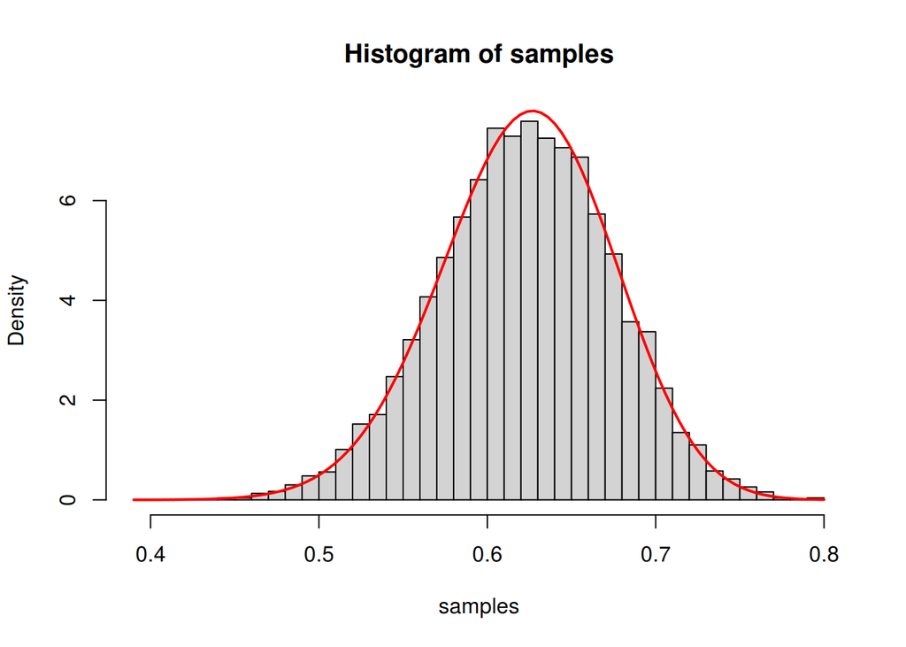

Figure 4.1: Histogram of samples from the multinomial mass function. The mass function is plotted as a red line.

```r
#Function f*(theta|y)
f_theta_given_y = function(theta) {
  y1 = 125
  y2 = 18
  y3 = 20
  y4 = 34
  f = (2+theta)^y1 * (1-theta)^(y2+y3) * theta^y4 # function f*(theta|y)
  return(f)
}

#Calculates acceptance probability
accept_prob = function(t) {
  c = optimize(f_theta_given_y, interval = c(0, 1), maximum = TRUE) # find maximum of f*, to use as the constant c
  alpha = f_theta_given_y(t) / c$objective # acceptance probability
  return(alpha)
}

#Samples from the multinomial mass function
sample_D1 = function(n) {
  X = 1:n
  for (i in 1:n) {
    accept = 0
    while(accept == 0) {
      u = runif(1) # sample from U[0,1]
      theta = runif(1) # sample from proposal density U[0,1]
      alpha = accept_prob(theta) # find the acceptance probability alpha
      if (u<=alpha) { # if u is smaller than the acceptance probability, the value for theta is accepted
        accept = 1
        X[i] = theta
      }
    }
  }
  return(X)
}

#The multinomial mass function
mass_function = function(theta) {
  int = integrate(f_theta_given_y, 0, 1) # integrate f*(theta|y) from 0 to 1
  c = 1 / (int$value) # use integral to find the normalizing constant
  return(c*f_theta_given_y(theta)) # f(theta|y)
}

#Tests the implementation
test_D1 = function(n) {
  samples = sample_D1(n)
  hist(samples, breaks = 30, freq = FALSE, main = bquote("Histogram of samples"))
  curve(mass_function, col = "red", lwd = 2, add=TRUE)
}

test_D1(10000)
```

The histogram above shows our samples, while the red line is the function we want to sample from. The line corresponds well with the histogram, which indicates that we have implemented out sampling algorithm correctly.

## 4.2 2

The posterior mean is given as
$$\begin{equation}
E(\theta|\vec y)=\int\theta f(\theta|\vec y)d\theta
\end{equation}$$
This integral can be approximated using Monte Carlo integration.

```r
#Function that uses Monte-Carlo integration to approximate the posterior mean
monte_carlo = function(M) {
  theta = sample_D1(M) # sample M values of theta
  est = 1/M * sum(theta) # use samples to estimate the mean
  return(est)
}

#The integrand of the posterior mean
func = function(theta) {
  y1 = 125
  y2 = 18
  y3 = 20
  y4 = 34

  f1 = f_theta_given_y(theta) # find f*(theta|y)
  int = integrate(f_theta_given_y, 0, 1) # integrate f*(theta|y) from 0 to 1
  c = 1 / (int$value) # use integral to find the normalizing constant
  f = c * f1 # f(theta|y) = cf*(theta|y)
  g = theta * f # the integrand needed to find the posterior mean
  return(g)
}

#Tests the implementation
test_D2 = function(M) {
  est = monte_carlo(M) # find estimate of the posterior mean using Monte Carlo integration
  real = integrate(func, 0, 1) # find the posterior mean using numerical integration
  post_mean = c(est, real)
  return(post_mean)
}

m = test_D2(10000)
```

When we use Monte Carlo integration we find that the posterior mean is 0.6224859. In order to test this result we have also calculated the posterior mean using a method of numerical integration in R, which gives us the value 0.6228061. These two result are fairly similar.

## 4.3 3

The expected number of iterations needed to find a $\theta$ that is accepted is $c\geq f(\theta|\vec y)/g(\theta)$, where $g(\theta)$ is the uniform distribution. Thus $c=\max_{\theta\in(0,1)}f(\theta|\vec y)$.

```r
#Checks how many iterations is needed to get a theta that is accepted
sample_D3 = function(n) {
  X = 1:n
  iterates = 0

  for (i in 1:n) {
    accept = 0
    while(accept == 0) {
      u = runif(1)
      theta = runif(1)
      alpha = accept_prob(theta)
      if (u<=alpha) {
        accept = 1
        X[i] = theta
      }
      iterates = iterates + 1
    }
  }
  average = iterates / n # average number of tries
  max_val = optimize(f_theta_given_y,interval=c(0,1),maximum = TRUE) # find the maximum value of f*
  c = integrate(f_theta_given_y,0,1)$value # Find the normalizing constant of f*
  expected = max_val$objective/c
  return(c(average,expected))
}

nr = sample_D3(10000)
```

Our algorithm uses approximately 7.9404 tries to find a value of $\theta$ that is accepted. Theoretically, we expect this number to be 7.7993075.

## 4.4 4

Now we want to look at a new prior, a the Beta(1,5) distribution. The new posterior distribution then becomes
$$\begin{equation}
f_{new}^* \propto (2+\theta)^{125}(1-\theta)^{42}\theta^{34}.
\end{equation}$$
From this we can find the weights
$$\begin{equation}
w(\theta) = \frac{f_{new}(\theta|\vec y)}{f(\theta|\vec y)} \propto \frac{\Gamma(1+5)}{\Gamma(1)\Gamma(5)}\theta^0(1-\theta)^4 = 5(1-\theta)^4
\end{equation}$$
Then we can find the self-normalizing mean
$$\begin{equation}
\tilde\mu_{IS}=\frac{\sum h(\theta_i)w(\theta_i)}{\sum w(\theta_i)}.
\end{equation}$$

```r
#Weights needed to estimate posterior mean
weights = function(theta) {
  w = 5 * (1-theta)^4 # calculate the weights
  return (w)
}

#Estimate the new posterior mean
mu_IS = function(n) {
  theta = sample_D1(n) # sample from
  w = weights(theta) # find the weights
  est = sum(theta*w) / sum(w) # calculate the self normalizing mean
  return(est)
}

# The new function of f*(theta|y), using beta(1,5) as a prior
f_new1 = function(theta) {
  y1 = 125
  y2 = 18
  y3 = 20
  y4 = 34
  f = (2+theta)^y1 * (1-theta)^(y2+y3+4) * theta^y4
  return(f)
}

# The new integrand needed to find the posterior mean
f_new = function(theta) {
  y1 = 125
  y2 = 18
  y3 = 20
  y4 = 34

  f1 = f_new1(theta) # find f*(theta|y)
  int = integrate(f_new1, 0, 1) # integrate f*(theta|y) from 0 to 1
  c = 1 / (int$value) # use integral to find the normalizing constant
  f = c * f1 # f(theta|y) = cf*(theta|y)
  g = theta * f # the integrand needed to find the posterior mean
  return(g)
}

#Tests the implementation
test_mu_IS = function(n) {
  est = mu_IS(n)
  real = integrate(f_new, 0, 1)
  return(c(est,real))
}

m = test_mu_IS(1000)
```

The self-normalizing mean becomes 0.5964292. In order to test this value we can use numerical integration. Then we get 0.5959316, which is fairly close to the value found from our simulation.